# Linear Algebra Basics

## Matrix-Vector multiplication

${}$

\begin{equation} \left\{\begin{matrix} c_1 \\ c_2 \\ c_3 \end{matrix}\right\} = \begin{bmatrix} a_{11} & a_{12} & a_{13} \\ a_{21} & a_{22} & a_{23} \\ a_{31} & a_{32} & a_{33} \end{bmatrix} \left\{\begin{matrix} b_1 \\ b_2 \\ b_3 \end{matrix}\right\} \end{equation}

$$ c_1 = a_{11} b_1 + a_{12} b_2 + a_{13} b_3 $$

$$ c_2 = a_{21} b_1 + a_{22} b_2 + a_{23} b_3 $$

$$ c_3 = a_{31} b_1 + a_{32} b_2 + a_{33} b_3 $$

**In words:** $c_i$ is the dot product of the $i^{\mbox{th}}$ row of $\mathbf{a}$ with $\vec{b}$...

## Matrix-Matrix multiplication

${}$

\begin{equation} \begin{bmatrix} c_{11} & c_{12} & c_{13} \\ c_{21} & c_{22} & c_{23} \\ c_{31} & c_{32} & c_{33} \end{bmatrix} = \begin{bmatrix} a_{11} & a_{12} & a_{13} \\ a_{21} & a_{22} & a_{23} \\ a_{31} & a_{32} & a_{33} \end{bmatrix} \begin{bmatrix} b_{11} & b_{12} & b_{13} \\ b_{21} & b_{22} & b_{23} \\ b_{31} & b_{32} & b_{33} \end{bmatrix} \end{equation}

$$ c_{11} = a_{11} b_{11} + a_{12} b_{21} + a_{13} b_{31} $$

\begin{align} c_{12} &= a_{11} b_{12} + a_{12} b_{22} + a_{13} b_{32} \\ & \vdots \end{align}

**In words:** $c_{ij}$ is the dot product of the $i^{\mbox{th}}$ row of $\mathbf{a}$ with the $j^{\mbox{th}}$ column of $\mathbf{b}$

# Examples

\begin{equation} \begin{bmatrix} 2 & 1 \\ 3 & 2 \end{bmatrix} \left\{ \begin{matrix} 1 \\ 2 \end{matrix}\right\} = \left\{\begin{matrix} 4 \\ 7 \end{matrix}\right\} \end{equation}

\begin{equation} \begin{bmatrix} 2 & 1 \\ 3 & 2 \end{bmatrix} \begin{bmatrix} 1 & 3 \\ 1 & 2 \end{bmatrix} = \begin{bmatrix} 3 & 8 \\ 5 & 13 \end{bmatrix} \end{equation}

# The determinant of a 2 x 2 matrix

${}$

$$ \mathbf{A} = \begin{bmatrix} a & b \\ c & d \end{bmatrix} $$

$$ \det(\mathbf{A}) = a \cdot d - b \cdot c $$

# The determinant of a 3 x 3 matrix

${}$

$$ \mathbf{A} = \begin{bmatrix} a & b & c\\ d & e & f\\ g & h & i \end{bmatrix} $$

$$ \det(\mathbf{A}) = a \cdot ( e \cdot i - f \cdot h ) - b \cdot ( d \cdot i - f \cdot g ) + c \cdot ( d \cdot h - e \cdot g) $$

# Matrix row operations

Used in solving matrix equations, i.e.

\begin{equation} \begin{bmatrix} a_{11} & a_{12} & a_{13} \\ a_{21} & a_{22} & a_{23} \\ a_{31} & a_{32} & a_{33} \end{bmatrix} \left\{ \begin{matrix} x_1 \\ x_2 \\ x_3 \end{matrix} \right\} = \left\{\begin{matrix} b_1 \\ b_2 \\ b_3 \end{matrix} \right\} \end{equation}

$$\mathbf{A}\vec{x} = \vec{b}$$

- Swaping rows doesn't change solution
- Adding rows together doesn't change solution
- Multiplying row by a scalar doesn't change solution

# Example

Solve for $\vec{x}$

\begin{equation} \begin{bmatrix} 2 & 3 & -2 \\ 0 & 0 & 3 \\ 1 & 0 & 2 \\ \end{bmatrix} \left\{ \begin{matrix} x_1 \\ x_2 \\ x_3 \end{matrix}\right\} = \left\{ \begin{matrix} 6 \\ -6 \\ 3 \end{matrix}\right\} \end{equation}

# Eigenvalue problem

${}$

$$ \mathbf{A} \vec{v} = \lambda \vec{v} $$

$$ \mathbf{A}\vec{v} - \lambda \vec{v} = 0 $$

$$ (\mathbf{A} - \lambda \mathbf{I})\vec{v} = 0 $$

A non-trivial solution for $\vec{v}$ exists, if and only if

$$ \det(\mathbf{A} - \lambda \mathbf{I}) = 0 $$

The $\lambda$'s are called the **eigenvalues**. Examples to follow in the context of stress.

# Vector transformation

${}$

$$ \vec{v}' = \mathbf{Q} \vec{v} $$

$$ \mathbf{Q} = \begin{bmatrix} \cos(\theta) & \sin(\theta) \\ -\sin(\theta) & \cos(\theta) \end{bmatrix} $$

# Matrix transformation

${}$

$$ \mathbf{S}' = \mathbf{Q}^{-1} \mathbf{S} \mathbf{Q} $$

If $\mathbf{Q}$ is chosen such that its columns are eigenvectors of $\mathbf{S}$, then $\mathbf{S}'$ will be *diagonal* with its entries cooresponding to the eigenvalues $\mathbf{S}$ (and $\mathbf{S}'$).

# Stress

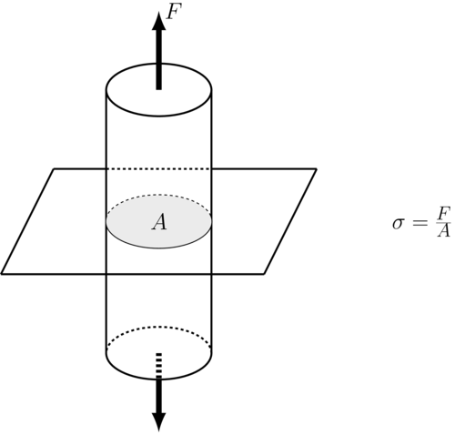

```python
%%tikz --scale 1.0 --size 500,500 -f png
\draw[line width=2] (0,5) ellipse [x radius=2, y radius=1];
\draw[line width=2, dashed] (2,-5) arc  (0:180:2 and 1);
\draw[line width=2] (2,-5) arc  (0:-180:2 and 1);
\draw[line width=2] (-2.0,5) -- (-2.0,-5);
\draw[line width=2] (2.0,5) -- (2.0,-5);
\draw[line width=6, -latex] (0.0,5) -- (0,8) node[right,text width=2] {\Huge $F$};
\draw[line width=6, -latex] (0.0,-6) -- (0,-8);
\draw[line width=6, dashed] (0.0,-5) -- (0,-6);
\draw[line width=2] (-6,-2) -- (4,-2);
\draw[line width=2] (-4,2) -- (-2,2);
\draw[line width=2, dashed] (-2,2) -- (2,2);
\draw[line width=2] (2,2) -- (6,2);
\draw[line width=2] (4,-2) -- (6,2);
\draw[line width=2] (-6,-2) -- (-4,2);
\draw[line width=2, dashed] (2,0) arc  (0:180:2 and 1);
\draw[line width=2] (2,0) arc  (0:-180:2 and 1);
\fill[line width=2, color=black!10] (2,0) arc  (0:180:2 and 1);
\fill[line width=2, color=black!10] (2,0) arc  (0:-180:2 and 1);
\node at (0,0) {\Huge $A$};
\node at (10,0) {\Huge $\sigma = \frac F A$};
```

# Cauchy tetrahedron

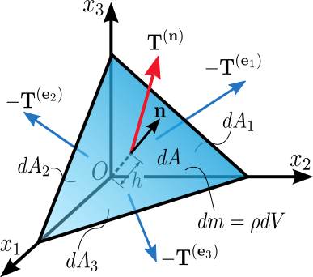

```python
IPython.display.Image(url='http://upload.wikimedia.org/wikipedia/commons/thumb/e/eb/Cauchy_tetrahedron.svg/387px-Cauchy_tetrahedron.svg.png', width=300, embed=True)
```

"[Cauchy tetrahedron](http://commons.wikimedia.org/wiki/File:Cauchy_tetrahedron.svg#mediaviewer/File:Cauchy_tetrahedron.svg)" by Sanpaz - Own work.  
Licensed under [CC BY-SA 3.0](http://creativecommons.org/licenses/by-sa/3.0) via Wikimedia Commons.

# Stress tensor

${}$

$$ \mathbf{\sigma} = \begin{bmatrix} \sigma_{11} & \sigma_{12} & \sigma_{13} \\ \sigma_{21} & \sigma_{22} & \sigma_{23} \\ \sigma_{31} & \sigma_{32} & \sigma_{33} \end{bmatrix} $$

# Visual definition

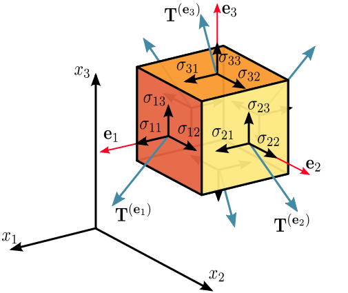

```python
IPython.display.Image(url='http://upload.wikimedia.org/wikipedia/commons/thumb/b/b3/Components_stress_tensor_cartesian.svg/505px-Components_stress_tensor_cartesian.svg.png', width=300, embed=True)
```

"[Components stress tensor cartesian](http://commons.wikimedia.org/wiki/File:Components_stress_tensor_cartesian.svg#mediaviewer/File:Components_stress_tensor_cartesian.svg)" by Sanpaz - Own work.  
Licensed under [CC BY-SA 3.0](http://creativecommons.org/licenses/by-sa/3.0) via Wikimedia Commons.

- First subscripted index refers to the index of the unit vector that is normal to the face.
- Second subscripted index refers to the component of traction vector.

[figure not shown]